# Reproducible Research: Peer Assessment 1

Load required libraries

```r
library(plyr)
library(ggplot2)
```

## Loading and preprocessing the data

Reading the data from activity.csv.

```r
actData= read.csv("./activity.csv",na.strings=c("NA", "NULL"))
```

Structure of the data looks like…

```r
str(actData)
```

```
## 'data.frame':    17568 obs. of  3 variables:
##  $ steps   : int  NA NA NA NA NA NA NA NA NA NA ...
##  $ date    : Factor w/ 61 levels "2012-10-01","2012-10-02",..: 1 1 1 1 1 1 1 1 1 1 ...
##  $ interval: int  0 5 10 15 20 25 30 35 40 45 ...
```

Data with ignoring mising values will be:

```r
subactData=subset(actData,! is.na(actData$steps))

str(subactData)
```

```
## 'data.frame':    15264 obs. of  3 variables:
##  $ steps   : int  0 0 0 0 0 0 0 0 0 0 ...
##  $ date    : Factor w/ 61 levels "2012-10-01","2012-10-02",..: 2 2 2 2 2 2 2 2 2 2 ...
##  $ interval: int  0 5 10 15 20 25 30 35 40 45 ...
```

## What is mean total number of steps taken per day?

Please Note:Missing values in the dataset are being ignored .

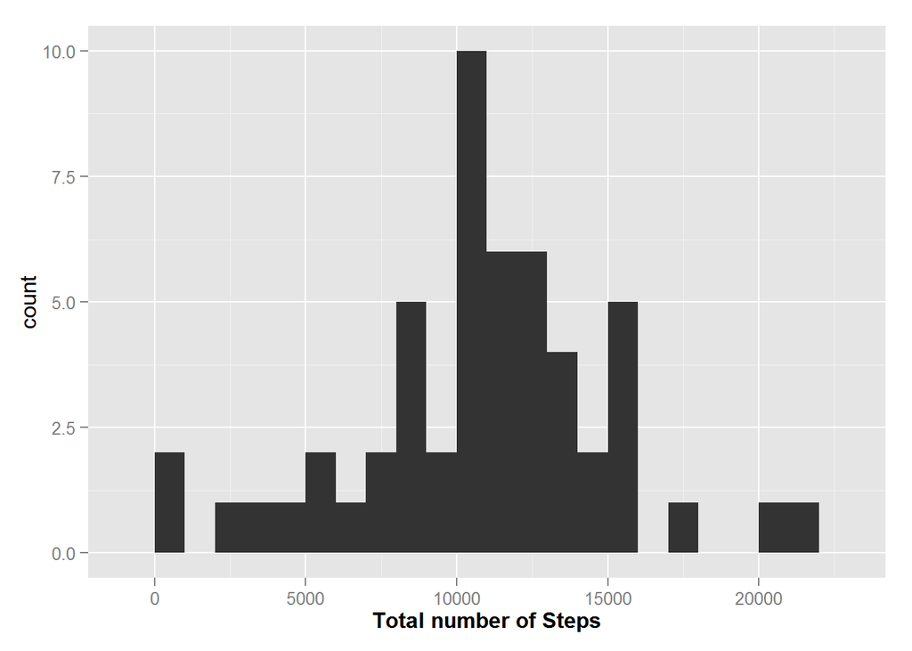

```r
datestepsdata=tapply(subactData$steps,subactData$date,sum)
dfdatestepsdata=as.data.frame(datestepsdata)
dfdatestepsdata[,2]=unique(actData$date)
names(dfdatestepsdata)=c("stepsmean","date")

qplot(dfdatestepsdata[,1], xlab = expression(bold("Total number of Steps")),  geom = "bar",binwidth=1000)
```

```r
meansteps=mean(dfdatestepsdata[,1],na.rm=TRUE)
medsteps=median(dfdatestepsdata[,1],na.rm=TRUE)
```

Mean of total number of steps taken per day is 1.0766 × 10<sup>4</sup>  
Median of total number of steps taken per day is 10765

## What is the average daily activity pattern?

Please Note:Missing values in the dataset are being ignored .

Time Series of 5-minute interval

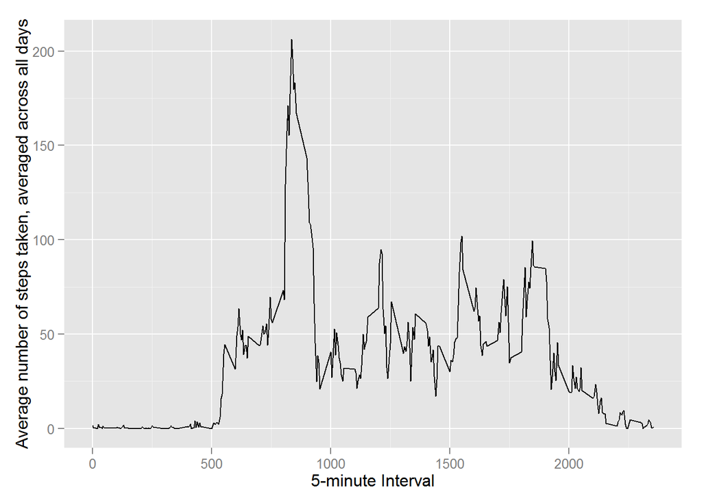

```r
intstepsdata=tapply(subactData$steps,subactData$interval,mean)
dfintstepsdata=as.data.frame(intstepsdata)
dfintstepsdata[,2]=unique(actData$interval)
names(dfintstepsdata)=c("avgdailysteps","interval")

ggplot(dfintstepsdata, aes( interval,avgdailysteps)) + geom_line() +    xlab("5-minute Interval") + ylab("Average number of steps taken, averaged across all days")
```

```r
maxsteps=max(dfintstepsdata$avgdailysteps)
intmaxsteps=dfintstepsdata[dfintstepsdata$avgdailysteps==maxsteps,]
```

5-minute Interval with maximum number of steps is 835

## Imputing missing values

1. Calculating total number f missin values in the dataset

```r
nacount=dim(actData[is.na(actData$steps),])[1]
```

Total number of rows with NA s are: 2304

============================ 2. Stratergy for filling in all of themissing Values in the dataset

We plan to impute missing values with mean of number steps of all observations

```r
impactData=actData
impactData[is.na(impactData$steps),]$steps=rep(mean(impactData$steps,na.rm=TRUE),nacount)
```

================================ 3. New Data after imputing missing value looks like:

```r
str ( impactData)
```

```
## 'data.frame':    17568 obs. of  3 variables:
##  $ steps   : num  37.4 37.4 37.4 37.4 37.4 ...
##  $ date    : Factor w/ 61 levels "2012-10-01","2012-10-02",..: 1 1 1 1 1 1 1 1 1 1 ...
##  $ interval: int  0 5 10 15 20 25 30 35 40 45 ...
```

================================ 4.Summarisizing new data and comparing with original:

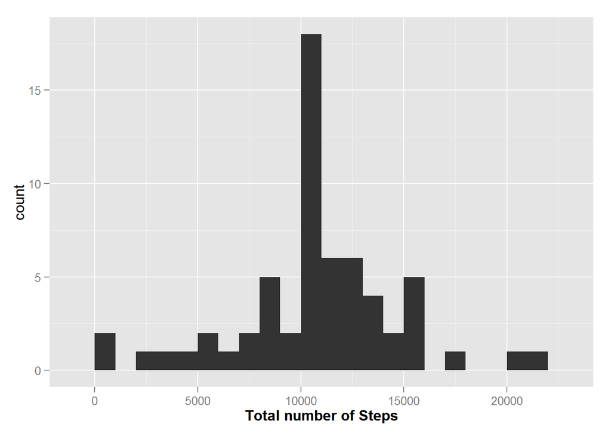

```r
newdatestepsdata=tapply(impactData$steps,impactData$date,sum)
newdfdatestepsdata=as.data.frame(newdatestepsdata)
newdfdatestepsdata[,2]=unique(actData$date)
names(newdfdatestepsdata)=c("stepsmean","date")

qplot(newdfdatestepsdata[,1], xlab = expression(bold("Total number of Steps")),  geom = "bar",binwidth=1000)
```

```r
newmeansteps=mean(newdfdatestepsdata[,1],na.rm=TRUE)
newmedsteps=median(newdfdatestepsdata[,1],na.rm=TRUE)
```

**We see very little difference in the estimates from earlier data set**

New Mean of total number of steps taken per day is 1.0766 × 10<sup>4</sup>  
Original Mean of total number of steps taken per day is 1.0766 × 10<sup>4</sup>

New Median of total number of steps taken per day is 1.0766 × 10<sup>4</sup>  
Original Median of total number of steps taken per day is 10765

## Are there differences in activity patterns between weekdays and weekends?

1. Creating a new factor variable to split the data as Weekend data and Weekday Data

```r
daylist=weekdays(as.POSIXlt(impactData$date))
ww=ifelse((daylist=="Sunday") | (daylist== "Saturday"),"Weekend","Weekday")

impactData["ww"]=as.factor(ww)
wwSplitData=split(impactData,impactData$ww)

weekendactData=wwSplitData$Weekend
weekdayactData=wwSplitData$Weekday

str(weekendactData)
```

```
## 'data.frame':    4608 obs. of  4 variables:
##  $ steps   : num  0 0 0 0 0 0 0 0 0 0 ...
##  $ date    : Factor w/ 61 levels "2012-10-01","2012-10-02",..: 6 6 6 6 6 6 6 6 6 6 ...
##  $ interval: int  0 5 10 15 20 25 30 35 40 45 ...
##  $ ww      : Factor w/ 2 levels "Weekday","Weekend": 2 2 2 2 2 2 2 2 2 2 ...
```

```r
str(weekdayactData)
```

```
## 'data.frame':    12960 obs. of  4 variables:
##  $ steps   : num  37.4 37.4 37.4 37.4 37.4 ...
##  $ date    : Factor w/ 61 levels "2012-10-01","2012-10-02",..: 1 1 1 1 1 1 1 1 1 1 ...
##  $ interval: int  0 5 10 15 20 25 30 35 40 45 ...
##  $ ww      : Factor w/ 2 levels "Weekday","Weekend": 1 1 1 1 1 1 1 1 1 1 ...
```

============================== 2. Compare Weekend activity with Weekday activity

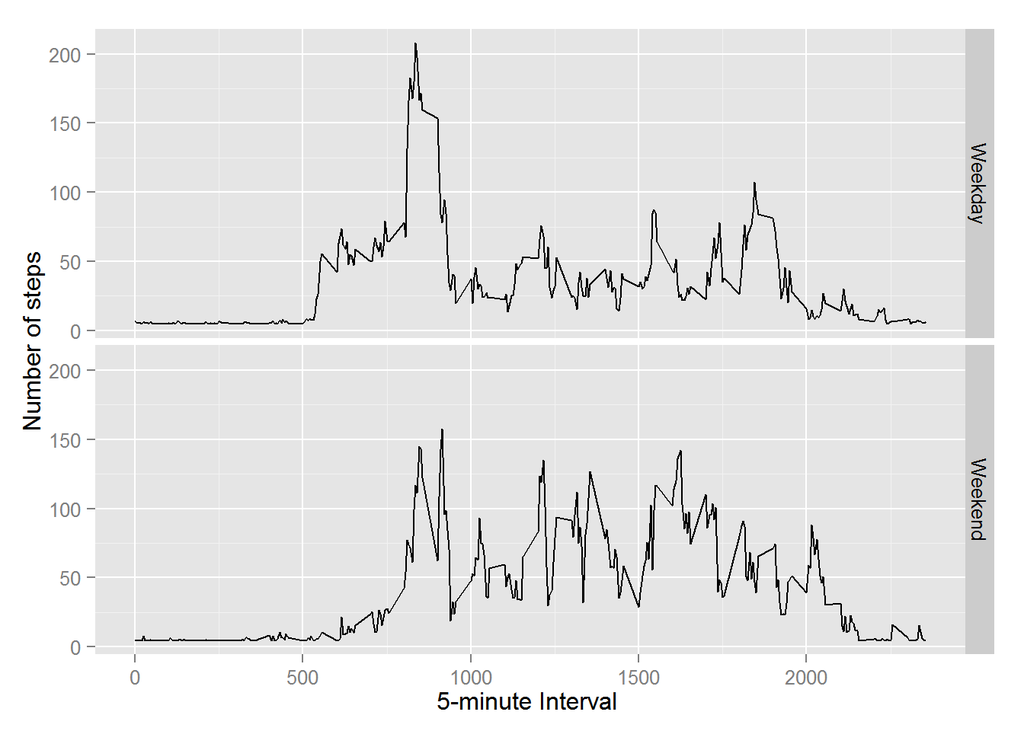

```r
## For weekend Data
WEintstepsdata=tapply(weekendactData$steps,weekendactData$interval,mean)
WEdfintstepsdata=as.data.frame(WEintstepsdata)
WEdfintstepsdata[,2]=unique(actData$interval)
WEdfintstepsdata[,3]=as.factor(rep("Weekend",nrow(WEdfintstepsdata)))
names(WEdfintstepsdata)=c("avgdailysteps","interval","WeekSplit")


## For Weekday Data
WDintstepsdata=tapply(weekdayactData$steps,weekdayactData$interval,mean)
WDdfintstepsdata=as.data.frame(WDintstepsdata)
WDdfintstepsdata[,2]=unique(actData$interval)
WDdfintstepsdata[,3]=as.factor(rep("Weekday",nrow(WDdfintstepsdata)))
names(WDdfintstepsdata)=c("avgdailysteps","interval","WeekSplit")

## Join the data
wwdfintstepsdata=rbind(WDdfintstepsdata,WEdfintstepsdata)


ggplot(wwdfintstepsdata, aes( interval,avgdailysteps)) + geom_line()+facet_grid(WeekSplit~.) +    xlab("5-minute Interval ") + ylab("Number of steps")
```